# Análisis de hechos delictivos - énfasis PNC

Los siguientes años seran descartados, ya que no se cuenta con una base de datos para su análisis

- 2009
- 2010
- 2013
- 2014
- 2015

Los siguiente años no cuentan con diccionario de variables, sin embargo con el archivo de tipo .sav, es posible observar las etiquetas de los datos. - 2021 - 2024

Instalación de librerias necesarias para cargar y manipular la información, la cual se encuetra en archivos de tipo sav. Si no las tiene instalasas en su equipo puede descomentar las líneas comentadas.

```r
#install.packages("haven")
#install.packages("dplyr")
#install.packages("arules")
#install.packages("ggplot2")
#install.packages("tidyr")
library(haven)
library(dplyr)
library(arules)
library(ggplot2)
library(tidyr)
```

La información que se carga a contnuación se encuentra en el repositorio, por lo que es necesario descargar el repositorio de manera completa para que no existan errores.

## Analisis de detenidos y victimas en el año 2011

### Cargando información de detenidos

```r
#carga de informacion
detenidos_data_2011  <- read_sav("../data/2011/detenidos.sav")
detenidos_data_2012  <- read_sav("../data/2012/detenidos.sav")
detenidos_data_2016  <- read_sav("../data/2016/detenidos.sav")
detenidos_data_2017  <- read_sav("../data/2017/detenidos.sav")
detenidos_data_2018  <- read_sav("../data/2018/detenidos.sav")
detenidos_data_2019  <- read_sav("../data/2019/detenidos.sav")
detenidos_data_2020  <- read_sav("../data/2020/detenidos.sav")
detenidos_data_2021  <- read_sav("../data/2021/detenidos.sav")
detenidos_data_2022  <- read_sav("../data/2022/detenidos.sav")
detenidos_data_2023  <- read_sav("../data/2023/detenidos.sav")
detenidos_data_2024  <- read_sav("../data/2024/detenidos.sav")
```

### Cargando información de víctimas

```r
victimas_data_2011 <- read_sav("../data/2011/victimas.sav")
victimas_data_2012 <- read_sav("../data/2012/victimas.sav")
victimas_data_2016 <- read_sav("../data/2016/victimas.sav")
victimas_data_2017 <- read_sav("../data/2017/victimas.sav")
victimas_data_2018 <- read_sav("../data/2018/victimas.sav")
victimas_data_2019 <- read_sav("../data/2019/victimas.sav")
victimas_data_2020 <- read_sav("../data/2020/victimas.sav")
victimas_data_2021 <- read_sav("../data/2021/victimas.sav")
victimas_data_2022 <- read_sav("../data/2022/victimas.sav")
victimas_data_2023 <- read_sav("../data/2023/victimas.sav")
victimas_data_2024 <- read_sav("../data/2024/victimas.sav")
```

### Exploración y limpieza de datos

Para poder explorar información de los distintos datasets se usaron instrucciones como las siguientes. Solo se fueron cambiando los datasets.

```r
#exploracion de valores en diccionario de datos

#detenidos
campo <- 'sexo_per'
attr(detenidos_data_2016[[campo]], "labels")
```

```
  Hombre    Mujer Ignorado
       1        2        9
```

```r
ls(detenidos_data_2016)
```

```
 [1] "año_ocu"             "área_geo_ocu"        "cód_int_Detenidos"   "delito_com"
 [5] "depto_ocu"           "día_ocu"             "día_sem_ocu"         "edad_per"
 [9] "edad_quinquenales"   "g_delitos"           "g_edad_60ymás"       "g_edad_80ymás"
[13] "g_hora"              "g_hora_mañ.tar.noch" "hora_ocu"            "menor_mayor"
[17] "mes_ocu"             "mupio_ocu"           "núm_corre"           "sexo_per"
[21] "zona_ocu"
```

```r
dim(detenidos_data_2016)
```

```
[1] 72761    21
```

```r
#victimas
campo <- 'sexo_per'
attr(victimas_data_2016[[campo]], "labels")
```

```
  Hombre    Mujer Ignorado
       1        2        9
```

```r
ls(victimas_data_2016)
```

```
 [1] "año_ocu"             "área_geo_ocu"        "delito_com"          "depto_ocu"
 [5] "día_ocu"             "día_sem_ocu"         "edad_per"            "edad_quinquenales"
 [9] "g_delitos"           "g_edad_60ymás"       "g_edad_80ymás"       "g_hora"
[13] "g_hora_mañ.tar.noch" "hora_ocu"            "menor_mayor"         "mes_ocu"
[17] "mupio_ocu"           "núm_corre"           "núm_corre_f"         "sexo_per"
[21] "zona_ocu"
```

```r
dim(victimas_data_2016)
```

```
[1] 38569    21
```

## Arreglando información de detenidos

Se busca unificar los dataset de detenidos en uno solo. Se agregan valores que corresponden a “ignorado” si el campo no existe o no se puede hallar de alguna manera, de lo contrario se realizan operaciones para encontrar el valor adecuado.

```r
#corrigiendo etiquetas

detenidos_data_2011_mod <- detenidos_data_2011 %>%
  mutate(across(where(is.labelled), as.numeric))

detenidos_data_2012_mod <- detenidos_data_2012 %>%
  mutate(across(where(is.labelled), as.numeric))

detenidos_data_2016_mod <- detenidos_data_2016 %>%
  mutate(across(where(is.labelled), as.numeric))

detenidos_data_2017_mod <- detenidos_data_2017 %>%
  mutate(across(where(is.labelled), as.numeric))

detenidos_data_2018_mod <- detenidos_data_2018 %>%
  mutate(across(where(is.labelled), as.numeric))

detenidos_data_2019_mod <- detenidos_data_2019 %>%
  mutate(across(where(is.labelled), as.numeric))

detenidos_data_2020_mod <- detenidos_data_2020 %>%
  mutate(across(where(is.labelled), as.numeric))

detenidos_data_2021_mod <- detenidos_data_2021 %>%
  mutate(across(where(is.labelled), as.numeric))

detenidos_data_2022_mod <- detenidos_data_2022 %>%
  mutate(across(where(is.labelled), as.numeric))

detenidos_data_2023_mod <- detenidos_data_2023 %>%
  mutate(across(where(is.labelled), as.numeric))

detenidos_data_2024_mod <- detenidos_data_2024 %>%
  mutate(across(where(is.labelled), as.numeric))

#arreglando data 2011
fix_data_detenidos_2011 <- detenidos_data_2011_mod %>%
  select(-numero_corre) %>%
  mutate(año_ocu = 2011) %>%
  mutate(día_ocu = 99)  %>%
  rename(día_sem_ocu  = dia_sem_ocu) %>%
  mutate(hora_ocu = 99)  %>%
  mutate(g_hora = 5)  %>%
  mutate(g_hora_mañ.tar.noch = 4)  %>%
  rename(área_geo_ocu  = areag_ocu) %>%
  mutate(zona_ocu = 99)  %>%
  rename(sexo_per  = sexo_dete) %>%
  rename(edad_per  = edad_dete) %>%
  mutate(g_edad_60ymás = 12)  %>%
  mutate(g_edad_80ymás = 16)  %>%
  mutate(edad_quinquenales = 18)  %>%
  mutate(menor_mayor = case_when(
    edad_per == 999 ~ 9,
    edad_per >= 18 ~ 1,
    edad_per < 18 ~ 2
  ))  %>%
  mutate(g_delitos = 9)  %>%
  rename(delito_com  = delito_infringido)


#arreglando data 2012
fix_data_detenidos_2012 <- detenidos_data_2012_mod %>%
  select(-numero_corre) %>%
  mutate(año_ocu = 2012) %>%
  rename(día_ocu = dia_ocu)  %>%
  mutate(día_sem_ocu  = 9) %>%
  mutate(hora_ocu = 99)  %>%
  mutate(g_hora = 5)  %>%
  mutate(g_hora_mañ.tar.noch = 4)  %>%
  rename(área_geo_ocu  = agrea_ocu) %>%
  mutate(mupio_ocu = 9)  %>%
  mutate(zona_ocu = 99)  %>%
  rename(sexo_per  = sexo_dete) %>%
  rename(edad_per  = edad_dete) %>%
  mutate(g_edad_60ymás = 12)  %>%
  mutate(g_edad_80ymás = 16)  %>%
  mutate(edad_quinquenales = 18)  %>%
  mutate(menor_mayor = case_when(
    edad_per == 999 ~ 9,
    edad_per >= 18 ~ 1,
    edad_per < 18 ~ 2
  ))  %>%
  mutate(g_delitos = 9)  %>%
  rename(delito_com  = causas)

#arreglando data 2016

fix_data_detenidos_2016 <- detenidos_data_2016_mod %>%
  select(-cód_int_Detenidos)

#arreglando data 2017


fix_data_detenidos_2017 <- detenidos_data_2017_mod %>%
  mutate(área_geo_ocu = 9) %>%
  relocate(área_geo_ocu, .after = g_hora_mañ.tar.noch)

#arreglando data 2018
fix_data_detenidos_2018 <- detenidos_data_2018_mod

#arreglando data 2019
fix_data_detenidos_2019 <- detenidos_data_2019_mod


#arreglando data 2020

fix_data_detenidos_2020 <- detenidos_data_2020_mod %>%
  mutate(área_geo_ocu = 9) %>%
  mutate(menor_mayor = case_when(
    edad_per == 999 ~ 9,
    edad_per >= 18 ~ 1,
    edad_per < 18 ~ 2
  ))


#arreglando data 2021

fix_data_detenidos_2021 <- detenidos_data_2021_mod %>%
  select(-`filter_$`) %>%
  mutate(área_geo_ocu = 9)  %>%
  mutate(menor_mayor = case_when(
    edad_per == 999 ~ 9,
    edad_per >= 18 ~ 1,
    edad_per < 18 ~ 2
  ))

#arreglando data 2022
fix_data_detenidos_2022 <- detenidos_data_2022_mod %>%
  mutate(menor_mayor = case_when(
    edad_per == 999 ~ 9,
    edad_per >= 18 ~ 1,
    edad_per < 18 ~ 2
  ))


#arreglando data 2023
fix_data_detenidos_2023 <- detenidos_data_2023_mod %>%
   mutate(menor_mayor = case_when(
    edad_per == 999 ~ 9,
    edad_per >= 18 ~ 1,
    edad_per < 18 ~ 2
  ))


#arreglando data 2024
fix_data_detenidos_2024 <- detenidos_data_2024_mod %>%
   mutate(menor_mayor = case_when(
    edad_per == 999 ~ 9,
    edad_per >= 18 ~ 1,
    edad_per < 18 ~ 2
  ))

detenidos_data_join <- bind_rows(
  fix_data_detenidos_2011,
  fix_data_detenidos_2012,
  fix_data_detenidos_2016,
  fix_data_detenidos_2017,
  fix_data_detenidos_2018,
  fix_data_detenidos_2019,
  fix_data_detenidos_2020,
  fix_data_detenidos_2021,
  fix_data_detenidos_2022,
  fix_data_detenidos_2023,
  fix_data_detenidos_2024,
)
detenidos_data_join <-  detenidos_data_join %>%
  select(-núm_corre)

nrow(detenidos_data_join)
```

```
[1] 581337
```

```r
# Sumando las filas de los datasets
total_filas_detenidos <- sum(
  nrow(detenidos_data_2011),
  nrow(detenidos_data_2012),
  nrow(detenidos_data_2016),
  nrow(detenidos_data_2017),
  nrow(detenidos_data_2018),
  nrow(detenidos_data_2019),
  nrow(detenidos_data_2020),
  nrow(detenidos_data_2021),
  nrow(detenidos_data_2022),
  nrow(detenidos_data_2023),
  nrow(detenidos_data_2024)
)

total_filas_detenidos
```

```
[1] 581337
```

```r
ls(detenidos_data_join)
```

```
 [1] "año_ocu"             "área_geo_ocu"        "delito_com"          "depto_ocu"
 [5] "día_ocu"             "día_sem_ocu"         "edad_per"            "edad_quinquenales"
 [9] "g_delitos"           "g_edad_60ymás"       "g_edad_80ymás"       "g_hora"
[13] "g_hora_mañ.tar.noch" "hora_ocu"            "menor_mayor"         "mes_ocu"
[17] "mupio_ocu"           "sexo_per"            "zona_ocu"
```

```r
dim(detenidos_data_join)
```

```
[1] 581337     19
```

## Arreglando información de victimas

Se busca unificar los dataset de víctimas en uno solo. Se agregan valores que corresponden a “ignorado” si el campo no existe o no se puede hallar de alguna manera, de lo contrario se realizan operaciones para encontrar el valor adecuado.

Luego de visualizar la información, y los datos que posee, se decide que se excluira los datos de 2011 y 2012 ya que los códigos que corresponden a las causas de delitos no se manejan de la misma manera en los otros dataset, es decir tienen un código diferente lo que puede ocacionar reglas incongruentes. Si se diera el caso de analizarse se analizara por separado.

```r
#corrigiendo etiquetas

victimas_data_2016_mod <- victimas_data_2016 %>%
  mutate(across(where(is.labelled), as.numeric))

victimas_data_2017_mod <- victimas_data_2017 %>%
  mutate(across(where(is.labelled), as.numeric))

victimas_data_2018_mod <- victimas_data_2018 %>%
  mutate(across(where(is.labelled), as.numeric))

victimas_data_2019_mod <- victimas_data_2019 %>%
  mutate(across(where(is.labelled), as.numeric))

victimas_data_2020_mod <- victimas_data_2020 %>%
  mutate(across(where(is.labelled), as.numeric))

victimas_data_2021_mod <- victimas_data_2021 %>%
  mutate(across(where(is.labelled), as.numeric))

victimas_data_2022_mod <- victimas_data_2022 %>%
  mutate(across(where(is.labelled), as.numeric))

victimas_data_2023_mod <- victimas_data_2023 %>%
  mutate(across(where(is.labelled), as.numeric))

victimas_data_2024_mod <- victimas_data_2024 %>%
  mutate(across(where(is.labelled), as.numeric))



#arreglando data 2016

fix_data_victimas_2016 <- victimas_data_2016_mod %>%
  select(-núm_corre_f, -hora_ocu)


#arreglando data 2017

fix_data_victimas_2017 <- victimas_data_2017_mod %>%
  mutate(área_geo_ocu = 9)

#arreglando data 2018
fix_data_victimas_2018 <- victimas_data_2018_mod %>%
  mutate(área_geo_ocu = 9)

#arreglando data 2019
fix_data_victimas_2019 <- victimas_data_2019_mod

#arreglando data 2020
fix_data_victimas_2020 <- victimas_data_2020_mod %>%
  mutate(área_geo_ocu = 9) %>%
  mutate(menor_mayor = case_when(
    edad_per == 999 ~ 9,
    edad_per >= 18 ~ 1,
    edad_per < 18 ~ 2
  ))

#arreglando data 2021
fix_data_victimas_2021 <- victimas_data_2021_mod %>%
  mutate(área_geo_ocu = 9) %>%
  mutate(menor_mayor = case_when(
    edad_per == 999 ~ 9,
    edad_per >= 18 ~ 1,
    edad_per < 18 ~ 2
  ))

#arreglando data 2022
fix_data_victimas_2022 <- victimas_data_2022_mod %>%
  mutate(menor_mayor = case_when(
    edad_per == 999 ~ 9,
    edad_per >= 18 ~ 1,
    edad_per < 18 ~ 2
  ))


#arreglando data 2023
fix_data_victimas_2023 <- victimas_data_2023_mod %>%
  mutate(menor_mayor = case_when(
    edad_per == 999 ~ 9,
    edad_per >= 18 ~ 1,
    edad_per < 18 ~ 2
  ))


#arreglando data 2024
fix_data_victimas_2024 <- victimas_data_2024_mod %>%
  mutate(menor_mayor = case_when(
    edad_per == 999 ~ 9,
    edad_per >= 18 ~ 1,
    edad_per < 18 ~ 2
  ))


  victimas_data_join <- bind_rows(
  fix_data_victimas_2016,
  fix_data_victimas_2017,
  fix_data_victimas_2018,
  fix_data_victimas_2019,
  fix_data_victimas_2020,
  fix_data_victimas_2021,
  fix_data_victimas_2022,
  fix_data_victimas_2023,
  fix_data_victimas_2024
)
victimas_data_join <-  victimas_data_join %>%
  select(-núm_corre)

nrow(victimas_data_join)
```

```
[1] 287323
```

```r
# Sumando las filas de los datasets
total_filas_victimas <- sum(
  nrow(victimas_data_2016),
  nrow(victimas_data_2017),
  nrow(victimas_data_2018),
  nrow(victimas_data_2019),
  nrow(victimas_data_2020),
  nrow(victimas_data_2021),
  nrow(victimas_data_2022),
  nrow(victimas_data_2023),
  nrow(victimas_data_2024)
)
total_filas_victimas
```

```
[1] 287323
```

```r
ls(victimas_data_join)
```

```
 [1] "año_ocu"             "área_geo_ocu"        "delito_com"          "depto_ocu"
 [5] "día_ocu"             "día_sem_ocu"         "edad_per"            "edad_quinquenales"
 [9] "g_delitos"           "g_edad_60ymás"       "g_edad_80ymás"       "g_hora"
[13] "g_hora_mañ.tar.noch" "hora_ocu"            "menor_mayor"         "mes_ocu"
[17] "mupio_ocu"           "sexo_per"            "zona_ocu"
```

```r
dim(victimas_data_join)
```

```
[1] 287323     19
```

### Reglas de asosiación y análisis de cluster

Se tienen los siguientes datasets para poder manipular y encontrar reglas así como las respectivas reglas

1. detenidos_data_join - Detenidos
2. victimas_data_join - Vícitmas
3. victimas_data_2011 - Víctimas
4. victimas_data_2012 - Víctimas

## Aplicando apriori

Apriori con detenidos.

```r
#reglas desde el 2011 al 2024 (reglas 6044)
reglas_apriori_detenidos <- apriori(detenidos_data_join, parameter = list(support = 0.2, confidence = 0.4))
```

```
Apriori

Parameter specification:
```

|  | confidence | minval | smax | arem | aval | originalSupport | maxtime | support | minlen | maxlen | target | ext |
| --- | --- | --- | --- | --- | --- | --- | --- | --- | --- | --- | --- | --- |
|  | 0.4 | 0.1 | 1 | none | FALSE | TRUE | 5 | 0.2 | 1 | 10 | rules | TRUE |

```
Algorithmic control:
```

|  | filter | tree | heap | memopt | load | sort | verbose |
| --- | --- | --- | --- | --- | --- | --- | --- |
|  | 0.1 | TRUE | TRUE | FALSE | TRUE | 2 | TRUE |

```
Absolute minimum support count: 116267

set item appearances ...[0 item(s)] done [0.00s].
set transactions ...[49 item(s), 581337 transaction(s)] done [0.82s].
sorting and recoding items ... [48 item(s)] done [0.12s].
creating transaction tree ... done [0.91s].
checking subsets of size 1 2 3 4 5 6 7 8 9 done [0.64s].
writing ... [10032 rule(s)] done [0.00s].
creating S4 object  ... done [0.14s].
```

```r
reglasFrameDetenidos <- as(reglas_apriori_detenidos, "data.frame")


#excluyendo grupos de edades reglas(239)
detenidos_f1 <- detenidos_data_join %>%
  select(-g_edad_60ymás, -g_edad_80ymás, -edad_quinquenales)


reglas_apriori_detenidos <- apriori(detenidos_f1, parameter = list(support = 0.1, confidence = 0.5))
```

```
Apriori

Parameter specification:
```

|  | confidence | minval | smax | arem | aval | originalSupport | maxtime | support | minlen | maxlen | target | ext |
| --- | --- | --- | --- | --- | --- | --- | --- | --- | --- | --- | --- | --- |
|  | 0.5 | 0.1 | 1 | none | FALSE | TRUE | 5 | 0.1 | 1 | 10 | rules | TRUE |

```
Algorithmic control:
```

|  | filter | tree | heap | memopt | load | sort | verbose |
| --- | --- | --- | --- | --- | --- | --- | --- |
|  | 0.1 | TRUE | TRUE | FALSE | TRUE | 2 | TRUE |

```
Absolute minimum support count: 58133

set item appearances ...[0 item(s)] done [0.00s].
set transactions ...[40 item(s), 581337 transaction(s)] done [0.73s].
sorting and recoding items ... [39 item(s)] done [0.11s].
creating transaction tree ... done [0.84s].
checking subsets of size 1 2 3 4 5 6 7 8 9 done [0.95s].
writing ... [37604 rule(s)] done [0.02s].
creating S4 object  ... done [0.12s].
```

```r
reglasFrameDetenidos <- as(reglas_apriori_detenidos, "data.frame")


#cambio en soporte(1771, 3505)
detenidos_f2 <- detenidos_data_join

reglas_apriori_detenidos <- apriori(detenidos_f2, parameter = list(support = 0.1, confidence = 0.5))
```

```
Apriori

Parameter specification:
```

|  | confidence | minval | smax | arem | aval | originalSupport | maxtime | support | minlen | maxlen | target | ext |
| --- | --- | --- | --- | --- | --- | --- | --- | --- | --- | --- | --- | --- |
|  | 0.5 | 0.1 | 1 | none | FALSE | TRUE | 5 | 0.1 | 1 | 10 | rules | TRUE |

```
Algorithmic control:
```

|  | filter | tree | heap | memopt | load | sort | verbose |
| --- | --- | --- | --- | --- | --- | --- | --- |
|  | 0.1 | TRUE | TRUE | FALSE | TRUE | 2 | TRUE |

```
Absolute minimum support count: 58133

set item appearances ...[0 item(s)] done [0.00s].
set transactions ...[49 item(s), 581337 transaction(s)] done [0.92s].
sorting and recoding items ... [48 item(s)] done [0.13s].
creating transaction tree ... done [0.80s].
checking subsets of size 1 2 3 4 5 6 7 8 9 10
```

```
 done [2.83s].
writing ... [123710 rule(s)] done [0.06s].
creating S4 object  ... done [0.18s].
```

```r
reglasFrameDetenidos <- as(reglas_apriori_detenidos, "data.frame")

#Solo capital(140 y 206)
detenidos_f3 <- detenidos_data_join %>%
  filter(depto_ocu == 1 ) %>%
  select(-depto_ocu)

reglas_apriori_detenidos <- apriori(detenidos_f3, parameter = list(support = 0.1, confidence = 0.5))
```

```
Apriori

Parameter specification:
```

|  | confidence | minval | smax | arem | aval | originalSupport | maxtime | support | minlen | maxlen | target | ext |
| --- | --- | --- | --- | --- | --- | --- | --- | --- | --- | --- | --- | --- |
|  | 0.5 | 0.1 | 1 | none | FALSE | TRUE | 5 | 0.1 | 1 | 10 | rules | TRUE |

```
Algorithmic control:
```

|  | filter | tree | heap | memopt | load | sort | verbose |
| --- | --- | --- | --- | --- | --- | --- | --- |
|  | 0.1 | TRUE | TRUE | FALSE | TRUE | 2 | TRUE |

```
Absolute minimum support count: 15271

set item appearances ...[0 item(s)] done [0.00s].
set transactions ...[45 item(s), 152715 transaction(s)] done [0.18s].
sorting and recoding items ... [43 item(s)] done [0.03s].
creating transaction tree ... done [0.15s].
checking subsets of size 1 2 3 4 5 6 7 8 9 10
```

```
 done [1.00s].
writing ... [151391 rule(s)] done [0.06s].
creating S4 object  ... done [0.06s].
```

```r
reglasFrameDetenidos <- as(reglas_apriori_detenidos, "data.frame")

dim(reglasFrameDetenidos)
```

```
[1] 151391      6
```

Apriori con victimas.

```r
#todos los datos(97, 109, 114)
reglas_apriori_victimas <- apriori(victimas_data_join, parameter = list(support = 0.2, confidence = 0.4))
```

```
Apriori

Parameter specification:
```

|  | confidence | minval | smax | arem | aval | originalSupport | maxtime | support | minlen | maxlen | target | ext |
| --- | --- | --- | --- | --- | --- | --- | --- | --- | --- | --- | --- | --- |
|  | 0.4 | 0.1 | 1 | none | FALSE | TRUE | 5 | 0.2 | 1 | 10 | rules | TRUE |

```
Algorithmic control:
```

|  | filter | tree | heap | memopt | load | sort | verbose |
| --- | --- | --- | --- | --- | --- | --- | --- |
|  | 0.1 | TRUE | TRUE | FALSE | TRUE | 2 | TRUE |

```
Absolute minimum support count: 57464

set item appearances ...[0 item(s)] done [0.00s].
set transactions ...[48 item(s), 287323 transaction(s)] done [0.38s].
sorting and recoding items ... [48 item(s)] done [0.06s].
creating transaction tree ... done [0.33s].
checking subsets of size 1 2 3 4 5 6 7 8 9 done [0.55s].
writing ... [8912 rule(s)] done [0.00s].
creating S4 object  ... done [0.07s].
```

```r
reglasFrameVictimas <- as(reglas_apriori_victimas, "data.frame")
```

## Aplicando FP-Growth

FP-Growth con detenidos

```r
#todos
reglas_fpgrowth_detenidos <- fim4r(detenidos_data_join, method ="fpgrowth", target = "rules", supp = .2, conf = .5)
```

```
fim4r.fpgrowth

Parameter specification:
```

|  | supp | conf | target | report |
| --- | --- | --- | --- | --- |
|  | 20 | 50 | rules | scl |

```
Data size: 581337 transactions and 49 items
Result: 9832 rules
```

```r
reglasFrameFpgDetenidos <- as(reglas_fpgrowth_detenidos, "data.frame")

#delito con mas apariciones

count_delitos <- detenidos_data_join %>%
  group_by(delito_com) %>%
  summarise(count = n())  %>%
  select(delito_com, count) %>%
  arrange(count)

detenidosFpg_f1 <- detenidos_data_join %>%
  filter(delito_com == 50) %>%
  select(-delito_com, -g_delitos)

reglas_fpgrowth_detenidos <- fim4r(detenidosFpg_f1, method ="fpgrowth", target = "rules", supp = .2, conf = .5)
```

```
fim4r.fpgrowth

Parameter specification:
```

|  | supp | conf | target | report |
| --- | --- | --- | --- | --- |
|  | 20 | 50 | rules | scl |

```
Data size: 97570 transactions and 44 items
Result: 4484 rules
```

```r
reglasFrameFpgDetenidos <- as(reglas_fpgrowth_detenidos, "data.frame")
```

FP-Growth con víctimas

```r
#todos
reglas_fpgrowth_victimas <- fim4r(victimas_data_join, method ="fpgrowth", target = "rules", supp = .2, conf = .5)
```

```
fim4r.fpgrowth

Parameter specification:
```

|  | supp | conf | target | report |
| --- | --- | --- | --- | --- |
|  | 20 | 50 | rules | scl |

```
Data size: 287323 transactions and 48 items
Result: 8704 rules
```

```r
reglasFrameFpgVictimas <- as(reglas_fpgrowth_victimas, "data.frame")

#solo capital
victimasFpg_f1 <- detenidos_data_join %>%
  filter(depto_ocu == 1) %>%
  select(-depto_ocu)
reglas_fpgrowth_victimas <- fim4r(victimasFpg_f1, method ="fpgrowth", target = "rules", supp = .2, conf = .5)
```

```
fim4r.fpgrowth

Parameter specification:
```

|  | supp | conf | target | report |
| --- | --- | --- | --- | --- |
|  | 20 | 50 | rules | scl |

```
Data size: 152715 transactions and 45 items
Result: 13588 rules
```

```r
reglasFrameFpgVictimas <- as(reglas_fpgrowth_victimas, "data.frame")

#solo menores
victimasFpg_f2 <- detenidos_data_join %>%
  filter(edad_per < 18) %>%
  select(-menor_mayor)

reglas_fpgrowth_victimas <- fim4r(victimasFpg_f2, method ="fpgrowth", target = "rules", supp = .2, conf = .5)
```

```
fim4r.fpgrowth

Parameter specification:
```

|  | supp | conf | target | report |
| --- | --- | --- | --- | --- |
|  | 20 | 50 | rules | scl |

```
Data size: 17825 transactions and 43 items
Result: 27704 rules
```

```r
reglasFrameFpgVictimas <- as(reglas_fpgrowth_victimas, "data.frame")
```

## Aplicando K-Means

Detenidos

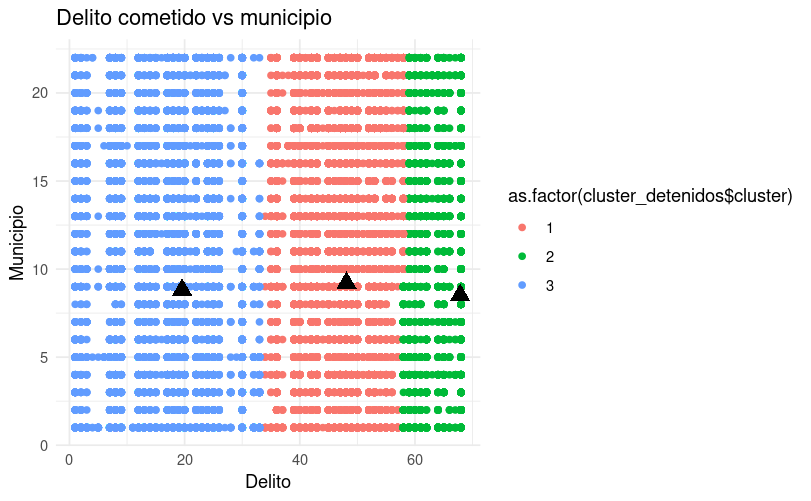

```r
#cluster delito departamento
detenidos_data_cluster <- detenidos_data_join %>%
  select(delito_com, depto_ocu)

cluster_detenidos <- kmeans(detenidos_data_cluster, centers=3)

ggplot(detenidos_data_cluster, aes(x = delito_com, y = depto_ocu, color = as.factor(cluster_detenidos$cluster)))+
  geom_point()+
  geom_point(data = as.data.frame(cluster_detenidos$centers), aes(x = delito_com, y = depto_ocu), color = "black", size=4, shape=17)+
  labs(title = "Delito cometido vs municipio",
       x = "Delito",
       y = "Municipio"
       )+
  theme_minimal()
```

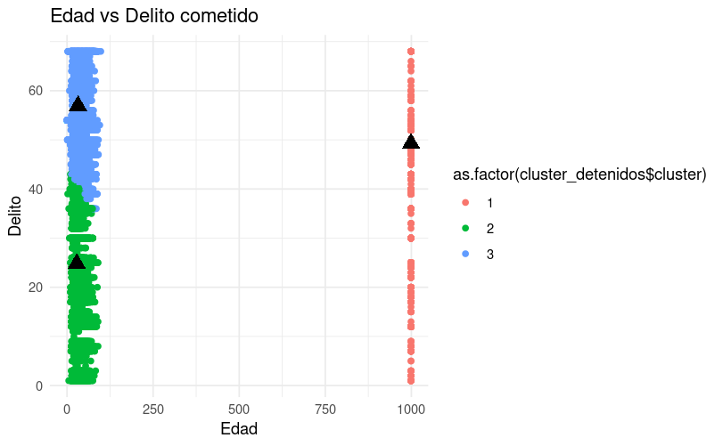

```r
#cluster edad, delito
detenidos_data_cluster <- detenidos_data_join %>%
  select(edad_per, delito_com) %>%
  drop_na()

cluster_detenidos <- kmeans(detenidos_data_cluster, centers=3)

ggplot(detenidos_data_cluster, aes(x = edad_per, y = delito_com, color = as.factor(cluster_detenidos$cluster)))+
  geom_point()+
  geom_point(data = as.data.frame(cluster_detenidos$centers), aes(x = edad_per , y = delito_com), color = "black", size=4, shape=17)+
  labs(title = "Edad vs Delito cometido",
       x = "Edad",
       y = "Delito"
       )+
  theme_minimal()
```

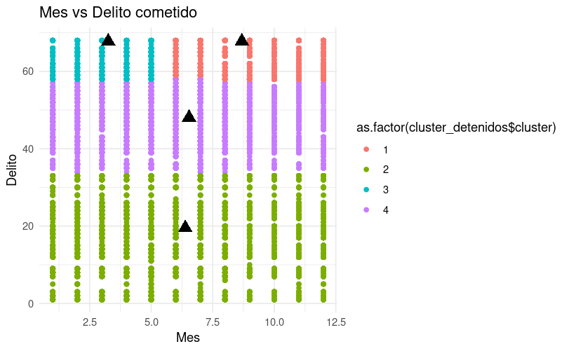

```r
#cluster mes, delito
detenidos_data_cluster <- detenidos_data_join %>%
  select(mes_ocu, delito_com) %>%
  drop_na()

cluster_detenidos <- kmeans(detenidos_data_cluster, centers=4)

ggplot(detenidos_data_cluster, aes(x = mes_ocu, y = delito_com, color = as.factor(cluster_detenidos$cluster)))+
  geom_point()+
  geom_point(data = as.data.frame(cluster_detenidos$centers), aes(x = mes_ocu , y = delito_com), color = "black", size=4, shape=17)+
  labs(title = "Mes vs Delito cometido",
       x = "Mes",
       y = "Delito"
       )+
  theme_minimal()
```

```r
NA
NA
NA
```

Víctimas

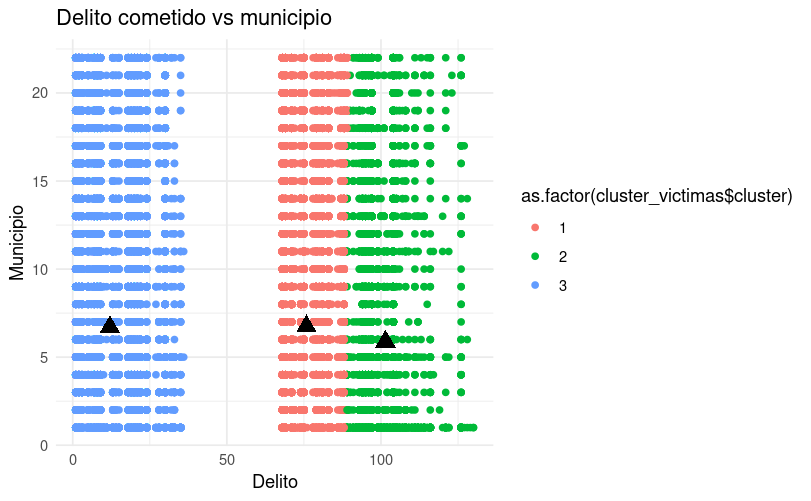

```r
#cluster delito departamento
victimas_data_cluster <- victimas_data_join %>%
  select(delito_com, depto_ocu)

cluster_victimas <- kmeans(victimas_data_cluster, centers=3)

ggplot(victimas_data_cluster, aes(x = delito_com, y = depto_ocu, color = as.factor(cluster_victimas$cluster)))+
  geom_point()+
  geom_point(data = as.data.frame(cluster_victimas$centers), aes(x = delito_com, y = depto_ocu), color = "black", size=4, shape=17)+
  labs(title = "Delito cometido vs municipio",
       x = "Delito",
       y = "Municipio"
       )+
  theme_minimal()
```

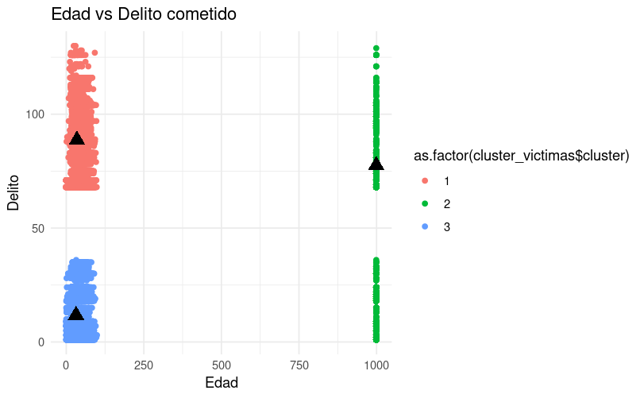

```r
#cluster edad, delito
victimas_data_cluster <- victimas_data_join %>%
  select(edad_per, delito_com) %>%
  drop_na()

cluster_victimas <- kmeans(victimas_data_cluster, centers=3)

ggplot(victimas_data_cluster, aes(x = edad_per, y = delito_com, color = as.factor(cluster_victimas$cluster)))+
  geom_point()+
  geom_point(data = as.data.frame(cluster_victimas$centers), aes(x = edad_per , y = delito_com), color = "black", size=4, shape=17)+
  labs(title = "Edad vs Delito cometido",
       x = "Edad",
       y = "Delito"
       )+
  theme_minimal()
```

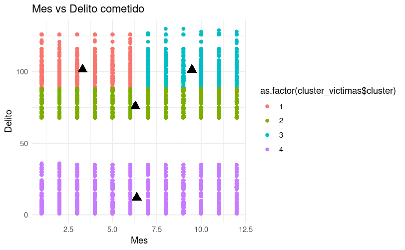

```r
#cluster mes, delito
victimas_data_cluster <- victimas_data_join %>%
  select(mes_ocu, delito_com) %>%
  drop_na()

cluster_victimas <- kmeans(victimas_data_cluster, centers=4)

ggplot(victimas_data_cluster, aes(x = mes_ocu, y = delito_com, color = as.factor(cluster_victimas$cluster)))+
  geom_point()+
  geom_point(data = as.data.frame(cluster_victimas$centers), aes(x = mes_ocu , y = delito_com), color = "black", size=4, shape=17)+
  labs(title = "Mes vs Delito cometido",
       x = "Mes",
       y = "Delito"
       )+
  theme_minimal()
```

```r
NA
NA
```